# Enfoque estadístico del aprendizaje

# **Trabajo práctico nº1: regresión lineal**

### **Datos a utilizar:**

Los datos con los que se trabajará en este TP provienen de la 3° Encuesta Mundial de Salud Escolar (EMSE) provistos por el Ministerio de Salud de la República Argentina. Esta encuesta trata sobre temas de salud y hábitos de las personas en la escuela secundaria que pueden impactar en su salud.

Los datasets que se comparten corresponden a un recorte (muestra) del dataset original, luego del tratamiento de valores atípicos e ingeniería de atributos.

Las **variables** incluidas son:

[output not shown]

### **Consignas:**

El objetivo general del trabajo es poder crear una serie de modelos lineales para explicar y predecir el peso de los estudiantes según la información que proporciona la EMSE.

Se cargan las librerías con las que se va a realizar el trabajo:

```r
library(tidyverse)
library(tidymodels)
library(ggplot2)
library(knitr)
library(GGally)
options(scipen=999)
```

Importo el dataset:

```r
encuesta_salud <- read.csv("encuesta_salud_train.csv")
```

#### **1) Análisis exploratorio**

Primero, observo algunos registros del dataset:

```r
encuesta_salud %>% sample_n(5)
```

| record | edad | genero | nivel_educativo | altura | peso | frecuencia_hambre_mensual | dias_consumo_comida_rapida | edad_consumo_alcohol | consumo_diario_alcohol | dias_actividad_fisica_semanal | consumo_semanal_frutas | consumo_semanal_verdura | consumo_semanal_gaseosas | consumo_semanal_snacks | consumo_semanal_comida_grasa |
| --- | --- | --- | --- | --- | --- | --- | --- | --- | --- | --- | --- | --- | --- | --- | --- |
| 39471 | 15 | Femenino | 2do año/11vo grado nivel Polimodal o 4to año nivel Secundario | 167 | 53 | Nunca | 0 | Nunca tomé alcohol más que unos pocos sorbos | 0 | 1 | 4 a 6 veces durante los últimos 7 días | 1 a 3 veces durante los últimos 7 días | No tomé gaseosas en los últimos 7 días | 1 a 3 veces durante los últimos 7 días | 1 a 3 veces durante los últimos 7 días |
| 43775 | 17 | Femenino | 2do año/11vo grado nivel Polimodal o 4to año nivel Secundario | 155 | 45 | Rara vez | 3 | Nunca tomé alcohol más que unos pocos sorbos | 0 | 3 | No comí frutas durante los últimos 7 días | 1 a 3 veces durante los últimos 7 días | 1 a 3 veces durante los últimos 7 días | 1 a 3 veces durante los últimos 7 días | 4 a 6 veces durante los últimos 7 días |
| 18336 | 13 | Masculino | 9no grado nivel Primario/Polimodal o 2do año nivel Secundario | 143 | 40 | Nunca | 3 | 10 o 11 años | 2 | 4 | 4 o más veces al día | 4 o más veces al día | 1 a 3 veces durante los últimos 7 días | 1 a 3 veces durante los últimos 7 días | 1 a 3 veces durante los últimos 7 días |
| 52066 | 14 | Femenino | 1er año/10mo grado nivel Polimodal o 3er año nivel Secundario | 157 | 45 | Nunca | 0 | 12 o 13 años | 3 | 0 | 1 a 3 veces durante los últimos 7 días | No comí verduras ni hortalizas durante los últimos 7 días | 4 o más veces al día | No comí comida salada o snacks en los últimos 7 días | 4 a 6 veces durante los últimos 7 días |
| 6831 | 16 | Masculino | Dato perdido | 162 | 48 | Algunas veces | 0 | 14 o 15 años | 0 | 1 | No comí frutas durante los últimos 7 días | 1 a 3 veces durante los últimos 7 días | 1 a 3 veces durante los últimos 7 días | 1 a 3 veces durante los últimos 7 días | No comí comida alta en grasa en los últimos 7 días |

Observo las dimensiones del dataset:

```r
glimpse(encuesta_salud)
```

```
Rows: 7,024
Columns: 16
$ record                        <int> 502, 26488, 31473, 14154, 36578, 53730, 11892, 35549, 14928, 11754, 40850, 11038, 32832, 31300, 32497, 6961, 3…
$ edad                          <int> 17, 15, 15, 16, 17, 15, 13, 17, 17, 16, 16, 14, 15, 17, 15, 14, 15, 17, 17, 16, 14, 12, 15, 17, 15, 16, 16, 16…
$ genero                        <chr> "Femenino", "Masculino", "Masculino", "Masculino", "Masculino", "Masculino", "Femenino", "Femenino", "Masculin…
$ nivel_educativo               <chr> "2do año/11vo grado nivel Polimodal o 4to año nivel Secundario", "1er año/10mo grado nivel Polimodal o 3er año…
$ altura                        <int> 165, 178, 172, 170, 170, 178, 156, 163, 164, 167, 185, 146, 180, 175, 183, 165, 165, 157, 165, 170, 174, 163, …
$ peso                          <int> 62, 62, 62, 65, 75, 88, 46, 60, 57, 51, 100, 33, 62, 70, 80, 60, 47, 50, 50, 70, 75, 55, 64, 59, 86, 51, 71, 4…
$ frecuencia_hambre_mensual     <chr> "Rara vez", "Rara vez", "Nunca", "Nunca", "Rara vez", "Nunca", "Nunca", "Nunca", "Nunca", "Nunca", "Nunca", "R…
$ dias_consumo_comida_rapida    <int> 0, 0, 3, 1, 1, 2, 0, 0, 0, 3, 4, 2, 1, 1, 3, 0, 0, 0, 0, 1, 0, 6, 0, 1, 0, 2, 0, 2, 0, 0, 5, 1, 0, 0, 1, 1, 0,…
$ edad_consumo_alcohol          <chr> "14 o 15 años", "7 años o menos", "Nunca tomé alcohol más que unos pocos sorbos", "14 o 15 años", "16 o 17 año…
$ consumo_diario_alcohol        <dbl> 5.0, 4.0, 0.0, 0.0, 0.0, 5.0, 1.0, 0.5, 5.0, 0.0, 5.0, 0.0, 0.0, 2.0, 1.0, 0.0, 5.0, 0.0, 1.0, 1.0, 0.5, 0.0, …
$ dias_actividad_fisica_semanal <int> 7, 7, 7, 7, 0, 7, 0, 2, 7, 3, 2, 2, 7, 1, 4, 0, 1, 6, 5, 7, 3, 0, 7, 5, 2, 2, 4, 2, 7, 4, 7, 0, 6, 4, 0, 3, 2,…
$ consumo_semanal_frutas        <chr> "No comí frutas durante los últimos 7 días", "No comí frutas durante los últimos 7 días", "No comí frutas dura…
$ consumo_semanal_verdura       <chr> "4 a 6 veces durante los últimos 7 días", "4 a 6 veces durante los últimos 7 días", "1 vez al día", "4 o más v…
$ consumo_semanal_gaseosas      <chr> "1 a 3 veces durante los últimos 7 días", "1 a 3 veces durante los últimos 7 días", "4 a 6 veces durante los ú…
$ consumo_semanal_snacks        <chr> "1 a 3 veces durante los últimos 7 días", "No comí comida salada o snacks en los últimos 7 días", "4 a 6 veces…
$ consumo_semanal_comida_grasa  <chr> "No comí comida alta en grasa en los últimos 7 días", "4 a 6 veces durante los últimos 7 días", "No comí comid…
```

Aquí se puede ver que el dataset cuenta con 7024 observaciones para las cuales se tienen 16 variables (7 de ellas numéricas y 9 categóricas). La variable peso, que es una de las variables numéricas, es la variable a explicar con el resto.

A continuación, observamos si las variables numéricas - y fundamentalmente el peso - están correlacionadas o no. Para ello, se procede a aperturar por el género de cada una de las personas:

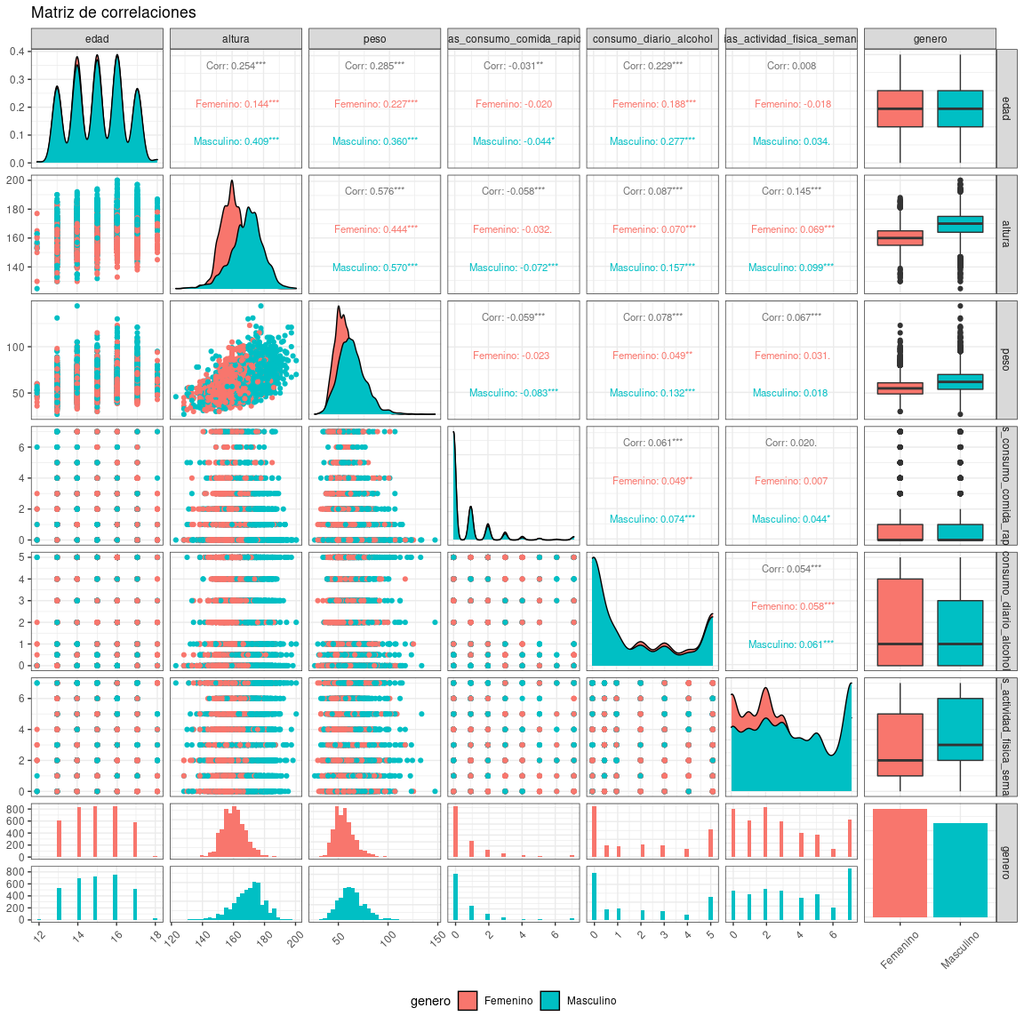

```r
encuesta_salud %>%
  select(where(is.numeric), genero, -record) %>%
  ggpairs(mapping = aes(color = genero), title = "Matriz de correlaciones",
          upper = list(continuous = wrap("cor", size = 3, hjust=0.5)), legend = 25) +
  theme_bw() +
  theme(axis.text.x = element_text(angle=45, vjust=0.5), legend.position = "bottom")
```

```r
encuesta_salud %>%
  group_by(genero) %>%
  summarise(cor = cor(altura, peso))
```

| genero | cor |
| --- | --- |
| Femenino | 0.4439202 |
| Masculino | 0.5704367 |

```r
NA
```

Luego, observamos qué categorías existen para la “frecuencia de hambre mensual”:

```r
encuesta_salud %>%
  select(frecuencia_hambre_mensual) %>%
  table() %>%
  prop.table() %>%
  sort(decreasing = TRUE)
```

```
frecuencia_hambre_mensual
        Nunca      Rara vez Algunas veces  Casi siempre  Dato perdido       Siempre
  0.689635535   0.206007973   0.083855353   0.011104784   0.005552392   0.003843964
```

```r
tabla = encuesta_salud %>%
  filter(frecuencia_hambre_mensual != 'Dato perdido') %>%
  filter(consumo_semanal_verdura != 'Dato perdido') %>%
  select(consumo_semanal_verdura, frecuencia_hambre_mensual) %>%
  table()
tabla = as.data.frame(tabla)
colnames(tabla) <- c("consumo_semanal_verdura", "frecuencia_hambre_mensual", "q")

order = c("Nunca", "Rara vez", "Algunas veces", "Casi siempre", "Siempre")
type = c("4 o más veces al día", "3 veces al día", "2 veces al día", "1 vez al día", "4 a 6 veces durante los últimos 7 días", "1 a 3 veces durante los últimos 7 días", "No comí verduras ni hortalizas durante los últimos 7 días")
```

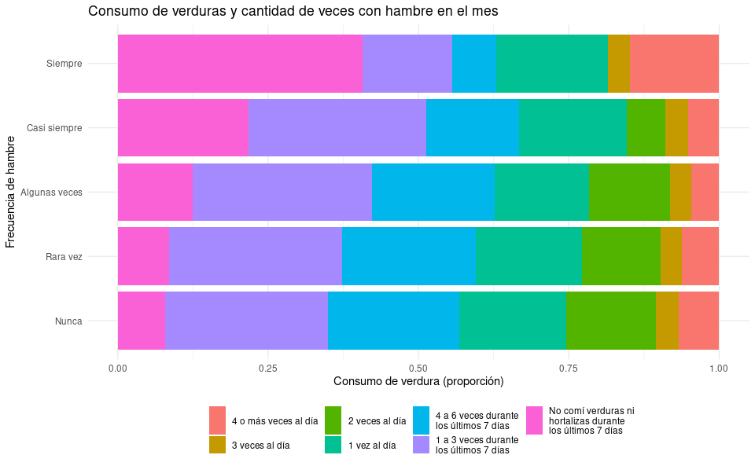

```r
ggplot(tabla) +
 aes(x = frecuencia_hambre_mensual,
     fill = factor(str_wrap(consumo_semanal_verdura, 20), levels = str_wrap(type, 20)),
     weight = q) +
 geom_bar(position = "fill") +
 scale_fill_hue(direction = 1) +
 coord_flip() +
 theme_minimal() +
 theme(legend.position = "bottom") +
 theme(legend.title=element_blank()) +
 labs(x = "Frecuencia de hambre",  y = "Consumo de verdura (proporción)", title = "Consumo de verduras y cantidad de veces con hambre en el mes") +
 scale_x_discrete(limits = order)
```

En estos gráficos, se puede observar que aquellos que suelen pasar hambre registran un menor consumo de verduras y hortalizas.

#### **2) Modelo inicial**

La primera alternativa para modelar el peso, es la siguiente:

$$E(peso) = \beta_{0} + \beta_{1} altura+ \beta_{2} edad+ \beta_{3} genero
+ \beta_{4} diasActividadF isicaSemanal + \beta_{5} consumoDiarioAlcohol$$

Ajusto el modelo lineal:

```r
modelo_simple = lm(peso ~ altura + edad + genero + dias_actividad_fisica_semanal + consumo_diario_alcohol, data=encuesta_salud)

tidy_modelo_simple <- tidy(modelo_simple, conf.int = TRUE)
tidy_modelo_simple
```

| term | estimate | std.error | statistic | p.value | conf.low | conf.high |
| --- | --- | --- | --- | --- | --- | --- |
| (Intercept) | -68.922688070 | 2.33805445 | -29.4786497 | 0.000000000000000000000000000000000000000000000000000000000000000000000000000000000000000000000000000000000000000000000000000000000000000000000000000000000000000000000000000000000003614866 | -73.5059810 | -64.33939510 |
| altura | 0.650606544 | 0.01437975 | 45.2446353 | 0.000000000000000000000000000000000000000000000000000000000000000000000000000000000000000000000000000000000000000000000000000000000000000000000000000000000000000000000000000000000000000000 | 0.6224179 | 0.67879520 |
| edad | 1.406727060 | 0.09385081 | 14.9889709 | 0.000000000000000000000000000000000000000000000000051215989492554911286730607609250788061186930061072962451657352751204024685720940152088355802479290164922992205657775198466056219837039265 | 1.2227511 | 1.59070300 |
| generoMasculino | 1.262643558 | 0.27282821 | 4.6279802 | 0.000003758830987839397557017740228446633921066677430644631385803222656250000000000000000000000000000000000000000000000000000000000000000000000000000000000000000000000000000000000000000000 | 0.7278179 | 1.79746926 |
| dias_actividad_fisica_semanal | -0.087391031 | 0.04992917 | -1.7503000 | 0.080110250029091112367041205288842320442199707031250000000000000000000000000000000000000000000000000000000000000000000000000000000000000000000000000000000000000000000000000000000000000000 | -0.1852673 | 0.01048523 |
| consumo_diario_alcohol | 0.007271379 | 0.06138558 | 0.1184542 | 0.905711181897899342274627088045235723257064819335937500000000000000000000000000000000000000000000000000000000000000000000000000000000000000000000000000000000000000000000000000000000000000 | -0.1130629 | 0.12760566 |

El valor de $\beta_{0}$ nos indica que el peso esperado para una mujer de 0 cm de altura, 0 años, que no realiza actividad física y que no consume alcohol es de -68.92 kg.

El coeficiente que multiplica a la altura $\beta_{1}$ es 0.65. Significa que ante cada cm adicional de altura el peso promedio aumenta en 0,65 kg manteniendo todas las otras variables constantes

El coeficiente que multiplica a generoMasculino es 1.26, de lo que se deduce que el peso esperado para una persona recién nacida de género masculino de 0 cm de altura, que no realiza actividad física ni consume alcohol es de -67,65 (-68.92 + 1.2626).

El valor de $\beta_{4}$ nos muestra que ante cada día de actividad física adicional el peso promedio disminuye en 0,08kg (manteniendo todas las otras variables constantes).

El valor de $\beta_{5}$ nos indica que ante cada trago diario adicional de alcohol el peso esperado de una persona aumenta en 0,007kg (manteniendo todas las otras variables constantes).

Sin embargo, no todas las variables son significativas. Tras realizar el test de significatividad individual para los días de actividad física semanal y para el consumo diario de alcohol se observan p-valores mayores a 0.05 por lo que no se rechaza la hipótesis nula ($\beta_{k}=0$). También se puede ver que los intervalos de confianza para ambos coeficientes contienen el 0, lo que nos da la pauta de que no son variables útiles para explicar el peso de una persona.

Por otro lado, el resto de las variables (altura, edad y género) sí resultan estadísticamente significativas para explicar el peso de una persona.

```r
glance(modelo_simple)
```

| r.squared | adj.r.squared | sigma | statistic | p.value | df | logLik | AIC | BIC | deviance | df.residual | nobs |
| --- | --- | --- | --- | --- | --- | --- | --- | --- | --- | --- | --- |
| 0.3543754 | 0.3539154 | 9.914373 | 770.4188 | 0 | 5 | -26076.58 | 52167.16 | 52215.15 | 689832.9 | 7018 | 7024 |

El $R^{2}$ del modelo, el porcentaje de variabilidad del fenómeno que el modelo logra explicar, es de 0,35. Considerando el p-valor, se rechaza la hipótesis nula del test de significatividad global y podemos concluir que al menos una de las variables regresoras sirve para explicar el peso de una persona.

#### **3) Modelo categóricas**

Luego, se probará con un modelo que incopore el consumo semanal de snacks y una interacción entre el género y la edad, en lugar de actividad física y consumo de alcohol:

$$E(peso) = \beta_{0} + \beta_{1} altura+ \beta_{2} edad+ \beta_{3} genero
+ \beta_{4} consumoSemanalSnacks + \beta_{5} genero.edad$$

Se harán algunas modificaciones para que el nivel basal del consumo semanal de snacks sea “no comí comida salada o snacks en los últimos 7 días:

```r
encuesta_salud$consumo_semanal_snacks <- relevel(as.factor(encuesta_salud$consumo_semanal_snacks), ref = "No comí comida salada o snacks en los últimos 7 días")

modelo_categoricas = lm(peso ~ altura + edad + genero + consumo_semanal_snacks + genero * edad, data=encuesta_salud)

tidy_modelo_categoricas <- tidy(modelo_categoricas, conf.int = TRUE)
tidy_modelo_categoricas
```

| term | estimate | std.error | statistic | p.value | conf.low | conf.high |
| --- | --- | --- | --- | --- | --- | --- |
| (Intercept) | -64.1994003 | 2.82848788 | -22.697428 | 0.00000000000000000000000000000000000000000000000000000000000000000000000000000000000000000000000000000000000004080837 | -69.74409176 | -58.6547088 |
| altura | 0.6429223 | 0.01452916 | 44.250469 | 0.00000000000000000000000000000000000000000000000000000000000000000000000000000000000000000000000000000000000000000000 | 0.61444077 | 0.6714039 |
| edad | 1.2230934 | 0.12102373 | 10.106228 | 0.00000000000000000000000754706503197907418391180246010737039496016082559346860373981457758424395976248888473492115736 | 0.98585034 | 1.4603365 |
| generoMasculino | -4.6115043 | 2.67876742 | -1.721502 | 0.08520382079197912073009746336538228206336498260498046875000000000000000000000000000000000000000000000000000000000000 | -9.86269837 | 0.6396898 |
| consumo_semanal_snacks1 a 3 veces durante los últimos 7 días | -1.3516324 | 0.27644506 | -4.889334 | 0.00000103428476720170872214918291603913402809666877146810293197631835937500000000000000000000000000000000000000000000 | -1.89354827 | -0.8097164 |
| consumo_semanal_snacks1 vez al día | -0.6078756 | 0.45601026 | -1.333031 | 0.18256509466496739779728386565693654119968414306640625000000000000000000000000000000000000000000000000000000000000000 | -1.50179360 | 0.2860424 |
| consumo_semanal_snacks2 veces al día | -1.0946603 | 0.68456905 | -1.599050 | 0.10985448360501090525609413361962651833891868591308593750000000000000000000000000000000000000000000000000000000000000 | -2.43662266 | 0.2473020 |
| consumo_semanal_snacks3 veces al día | -1.2759618 | 1.01150207 | -1.261452 | 0.20718783152043493411831320827332092449069023132324218750000000000000000000000000000000000000000000000000000000000000 | -3.25881168 | 0.7068881 |
| consumo_semanal_snacks4 a 6 veces durante los últimos 7 días | -2.2700362 | 0.44992485 | -5.045367 | 0.00000046403175018657054949156124529219269447821716312319040298461914062500000000000000000000000000000000000000000000 | -3.15202493 | -1.3880474 |
| consumo_semanal_snacks4 o más veces al día | -2.5669735 | 0.88112366 | -2.913295 | 0.00358765781176550091133292674783206166466698050498962402343750000000000000000000000000000000000000000000000000000000 | -4.29424225 | -0.8397047 |

[output cut: 2 more lines]

```r
NA
```

¿Cuál es la interpretación de los coeficientes estimados para las categorías de consumoSemanalSnacks y genero . edad? ¿Son significativas? ¿Qué porcentaje de la variabilidad explica el modelo?

```r
tidy(anova(modelo_simple))
```

| term | df | sumsq | meansq | statistic | p.value |
| --- | --- | --- | --- | --- | --- |
| altura | 1 | 354474.064098 | 354474.064098 | 3606.23418703 | 0.0000000000000000000000000000000000000000000000000000000 |
| edad | 1 | 21885.934025 | 21885.934025 | 222.65607414 | 0.0000000000000000000000000000000000000000000000001364382 |
| genero | 1 | 1979.608636 | 1979.608636 | 20.13950544 | 0.0000073142797097086264764866092580319900662289001047611 |
| dias_actividad_fisica_semanal | 1 | 299.801198 | 299.801198 | 3.05002097 | 0.0807798500403074520859192375610291492193937301635742188 |
| consumo_diario_alcohol | 1 | 1.379213 | 1.379213 | 0.01403139 | 0.9057111818978993422746270880452357232570648193359375000 |
| Residuals | 7018 | 689832.898480 | 98.294799 | NA | NA |

En caso de detectar que existen categorías no significativas de la variable consumoSemanalSnacks evaluar si la variable es significativa en su conjunto y, en caso afirmativo, proponer una redefinición de las mismas que permita obtener una mayor proporción de categorías significativas individualmente.

Luego, analizar si existen cambios en la variabilidad explicada por el modelo.

#### **4) Modelos propios y evaluación**

Realizar 2 modelos lineales múltiples adicionales y explicar brevemente la lógica detrás de los mismos (se valorará la creación y/o inclusión de variables nuevas).

Evaluar la performance del modelo inicial, el modelo categóricas con las categorías redefinidas de la variable consumoSemanalSnacks y los modelos desarrollados en este punto en el dataset de entrenamiento y evaluación (usar dataset “encuesta_salud_test.csv”). La evaluación de performance consiste en comparar la performance en términos del R cuadrado ajustado, RMSE y MAE sobre el set de entrenamiento y en términos de RMSE y MAE sobre el set de evaluación.

¿Cuál es el mejor modelo para nuestro objetivo de predecir el peso? ¿Por qué?

#### **5) Diagnóstico del modelo**

Analizar en profundidad el cumplimiento de los supuestos del modelo lineal para el modelo inicial.

```r
plot(modelo_simple)
```

[output not shown]

#### **6) Modelo robusto**

Leer el archivo “encuesta_salud_modelo6.csv”. Este último consiste en el dataset original de train con la incorporación de algunas observaciones adicionales que pueden incluir valores atípicos. En particular, observar la relación entre peso y altura ¿Qué ocurre con estos nuevos datos?

Entrenar el modelo inicial con estos nuevos datos y comentar qué se observa en los coeficientes estimados y las métricas de evaluación (R cuadrado ajustado, RMSE y MAE) respecto al modelo entrenado con el set de entrenamiento original. Entrenar un modelo robusto con la misma especificación que el modelo inicial sobre los nuevos datos. Comparar los coeficientes y su performance (RMSE y MAE) respecto al modelo inicial no robusto entrenado en este punto. ¿Qué puede concluir al respecto? Nota: los registros que se suman en este punto son observaciones ficticias que se generaron a partir de observaciones reales del set de datos original.